# ISA 365 Exam 2 Output Packet

Last complied on November 15, 2022

### Soft Drink Displays

A soft drink distributor knows that end-aisle displays are an effective way to increase sales of the product. There are several ways to design these displays, varying the text, the colors, and the visual images. The marketing group has designed three new end-aisle displays and wants to test their effectiveness. They have identified 15 stores of similar size to participate in the study. Each store will test one of the displays for a period of one month. The company knows there are store to store differences but are not interested in study those differences.

| Store | Design.Display | Percent.Increase.in.Sales |
| --- | --- | --- |
| 1 | 1 | 5.43 |
| 2 | 1 | 5.71 |
| 3 | 1 | 6.22 |
| 4 | 1 | 6.01 |
| 5 | 1 | 5.29 |
| 6 | 2 | 6.24 |
| 7 | 2 | 6.71 |
| 8 | 2 | 5.98 |
| 9 | 2 | 5.66 |
| 10 | 2 | 6.60 |
| 11 | 3 | 8.79 |
| 12 | 3 | 9.20 |
| 13 | 3 | 7.90 |
| 14 | 3 | 8.15 |
| 15 | 3 | 7.55 |

#### Suggested Analysis Results

```
##                Df Sum Sq Mean Sq F value   Pr(>F)
## Design.Display  1 16.718  16.718   41.68 2.15e-05 ***
## Residuals      13  5.215   0.401
## ---
## Signif. codes:  0 '***' 0.001 '**' 0.01 '*' 0.05 '.' 0.1 ' ' 1
```

```
##                Df Sum Sq Mean Sq F value   Pr(>F)
## Design.Display  2  18.78   9.392   35.77 8.78e-06 ***
## Residuals      12   3.15   0.263
## ---
## Signif. codes:  0 '***' 0.001 '**' 0.01 '*' 0.05 '.' 0.1 ' ' 1
```

### Soft Drink Displays–Small Company

A smaller company is also interested in testing these three soft drink displays. This company chooses to test these displays in each of 5 stores. This smaller company knows there are store to store differences but they are not interested in studying those differences.

| Store | Design.Display | Percent.Increase.in.Sales |
| --- | --- | --- |
| 1 | 1 | 5.43 |
| 1 | 2 | 6.24 |
| 1 | 3 | 8.79 |
| 2 | 1 | 5.71 |
| 2 | 2 | 6.71 |
| 2 | 3 | 9.20 |
| 3 | 1 | 6.22 |
| 3 | 2 | 5.98 |
| 3 | 3 | 7.90 |
| 4 | 1 | 6.01 |
| 4 | 2 | 5.66 |
| 4 | 3 | 8.15 |
| 5 | 1 | 5.29 |
| 5 | 2 | 6.60 |
| 5 | 3 | 7.55 |

#### Suggested Analysis Results

```
##                Df Sum Sq Mean Sq F value   Pr(>F)
## Design.Display  1 16.718  16.718   41.68 2.15e-05 ***
## Residuals      13  5.215   0.401
## ---
## Signif. codes:  0 '***' 0.001 '**' 0.01 '*' 0.05 '.' 0.1 ' ' 1
```

```
##                Df Sum Sq Mean Sq F value   Pr(>F)
## Design.Display  2  18.78   9.392   35.77 8.78e-06 ***
## Residuals      12   3.15   0.263
## ---
## Signif. codes:  0 '***' 0.001 '**' 0.01 '*' 0.05 '.' 0.1 ' ' 1
```

```
##                Df Sum Sq Mean Sq F value   Pr(>F)
## Design.Display  2 18.783   9.392  38.853 1.03e-05 ***
## Store           1  0.492   0.492   2.033    0.182
## Residuals      11  2.659   0.242
## ---
## Signif. codes:  0 '***' 0.001 '**' 0.01 '*' 0.05 '.' 0.1 ' ' 1
```

```
##                Df Sum Sq Mean Sq F value   Pr(>F)
## Design.Display  2 18.783   9.392  33.772 0.000126 ***
## Store           4  0.926   0.231   0.832 0.540910
## Residuals       8  2.225   0.278
## ---
## Signif. codes:  0 '***' 0.001 '**' 0.01 '*' 0.05 '.' 0.1 ' ' 1
```

### Store Display–New Company

A new, small company wishes to execute the same type of test for the Soft Drink display. This company has 3 stores to run the tests. They will use 3 months, 1 month per display, to run the tests. The company knows there are store to store and month to month differences but they wish to make conclusions regardless of store and month.

| Store | Month | Design.Display | Percent.Increase.in.Sales |
| --- | --- | --- | --- |
| 1 | 1 | 1 | 5.43 |
| 1 | 2 | 2 | 6.24 |
| 1 | 3 | 3 | 8.79 |
| 2 | 1 | 2 | 6.71 |
| 2 | 2 | 3 | 9.20 |
| 2 | 3 | 1 | 5.71 |
| 3 | 1 | 3 | 7.90 |
| 3 | 2 | 1 | 6.22 |
| 3 | 3 | 2 | 5.66 |

#### Suggested Analysis Results

```
##                Df Sum Sq Mean Sq F value Pr(>F)
## Design.Display  1 12.127  12.127  19.662 0.0044 **
## Store           1  0.077   0.077   0.125 0.7358
## Residuals       6  3.701   0.617
## ---
## Signif. codes:  0 '***' 0.001 '**' 0.01 '*' 0.05 '.' 0.1 ' ' 1
```

```
##                Df Sum Sq Mean Sq F value  Pr(>F)
## Design.Display  1 12.127  12.127  16.396 0.00983 **
## Store           1  0.077   0.077   0.104 0.75991
## Month           1  0.002   0.002   0.003 0.95678
## Residuals       5  3.698   0.740
## ---
## Signif. codes:  0 '***' 0.001 '**' 0.01 '*' 0.05 '.' 0.1 ' ' 1
```

```
##                Df Sum Sq Mean Sq F value Pr(>F)
## Design.Display  2 14.147   7.073  22.199 0.0431 *
## Store           2  0.577   0.289   0.906 0.5248
## Month           2  0.543   0.272   0.852 0.5398
## Residuals       2  0.637   0.319
## ---
## Signif. codes:  0 '***' 0.001 '**' 0.01 '*' 0.05 '.' 0.1 ' ' 1
```

```r
TukeyHSD(mod)
```

```
##   Tukey multiple comparisons of means
##     95% family-wise confidence level
##
## Fit: aov(formula = Percent.Increase.in.Sales ~ Design.Display + Store + Month, data = df)
##
## $Design.Display
##          diff        lwr      upr     p adj
## 2-1 0.4166667 -2.2983392 3.131673 0.6898715
## 3-1 2.8433333  0.1283275 5.558339 0.0457918
## 3-2 2.4266667 -0.2883392 5.141673 0.0618053
##
## $Store
##           diff       lwr      upr     p adj
## 2-1  0.3866667 -2.328339 3.101673 0.7208609
## 3-1 -0.2266667 -2.941673 2.488339 0.8824345
## 3-2 -0.6133333 -3.328339 2.101673 0.5069033
##
## $Month
##      diff       lwr      upr     p adj
## 2-1  0.54 -2.175006 3.255006 0.5699960
## 3-1  0.04 -2.675006 2.755006 0.9958646
## 3-2 -0.50 -3.215006 2.215006 0.6071826
```

### Verizon Plan Pricing

Verizon has recently implemented mix and match plans for each line. In order to optimize the plan pricing they tested 3 different versions of the “Get More” Plan. They tested the three different versions over the course of one month and measured the number of plan sign-ups during this time.

| plan | sign_up |
| --- | --- |
| A | 0 |
| A | 0 |
| A | 0 |
| A | 0 |
| A | 0 |
| A | 0 |

```r
library(tidyverse)
df %>% group_by(plan, sign_up) %>% summarise(n=n()) %>% mutate(n/sum(n))
```

```
## # A tibble: 6 × 4
## # Groups:   plan [3]
##   plan  sign_up     n `n/sum(n)`
##   <chr>   <int> <int>      <dbl>
## 1 A           0  4763     0.973
## 2 A           1   134     0.0274
## 3 B           0  4823     0.965
## 4 B           1   177     0.0354
## 5 C           0  4857     0.971
## 6 C           1   143     0.0286
```

### Direct Mail Experiment

An article in the International Journal of Research in Marketing describes an experiment to test new ideas to increase direct mail sales by the credit card division of a financial services company. They know from experience that the interest rates are an important factor in attracting potential customers so they have decided to focus on factors involving both interest rates and fees. They want to test changes in both introductory and long term rates as well as the effects of adding an account-opening fee and lowering the annual fee. The factors tested are as follows:

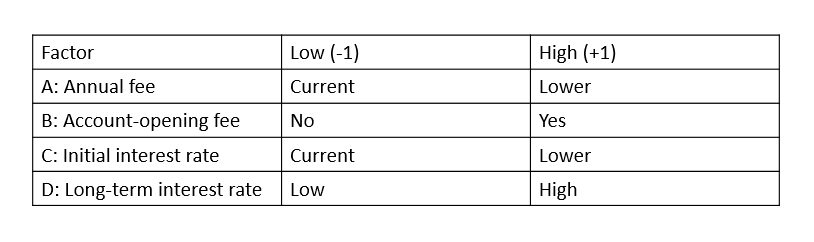

The company measured the response rate to each offer. 7500 people were sent each offer as generated by the factors listed above.

| Run | A | B | C | D | response.rate |
| --- | --- | --- | --- | --- | --- |
| 1 | -1 | -1 | -1 | -1 | 0.0245333 |
| 2 | 1 | -1 | -1 | -1 | 0.0336000 |
| 3 | -1 | 1 | -1 | -1 | 0.0216000 |
| 4 | 1 | 1 | -1 | -1 | 0.0229333 |
| 5 | -1 | -1 | 1 | -1 | 0.0249333 |
| 6 | 1 | -1 | 1 | -1 | 0.0338667 |
| 7 | -1 | 1 | 1 | -1 | 0.0232000 |
| 8 | 1 | 1 | 1 | -1 | 0.0244000 |
| 9 | -1 | -1 | -1 | 1 | 0.0184000 |
| 10 | 1 | -1 | -1 | 1 | 0.0224000 |
| 11 | -1 | 1 | -1 | 1 | 0.0169333 |
| 12 | 1 | 1 | -1 | 1 | 0.0186667 |
| 13 | -1 | -1 | 1 | 1 | 0.0229333 |
| 14 | 1 | -1 | 1 | 1 | 0.0292000 |
| 15 | -1 | 1 | 1 | 1 | 0.0204000 |
| 16 | 1 | 1 | 1 | 1 | 0.0202667 |

#### Model 1

```
##
## Call:
## lm(formula = response.rate ~ A * B * C * D, data = df)
##
## Residuals:
## ALL 16 residuals are 0: no residual degrees of freedom!
##
## Coefficients:
##                 Estimate Std. Error t value Pr(>|t|)
## (Intercept)  0.023641667        NaN     NaN      NaN
## A            0.002025000        NaN     NaN      NaN
## B           -0.002591667        NaN     NaN      NaN
## C            0.001258333        NaN     NaN      NaN
## D           -0.002491667        NaN     NaN      NaN
## A:B         -0.001508333        NaN     NaN      NaN
## A:C          0.000008333        NaN     NaN      NaN
## B:C         -0.000241667        NaN     NaN      NaN
## A:D         -0.000541667        NaN     NaN      NaN
## B:D          0.000508333        NaN     NaN      NaN
## C:D          0.000791667        NaN     NaN      NaN
## A:B:C       -0.000258333        NaN     NaN      NaN
## A:B:D        0.000425000        NaN     NaN      NaN
## A:C:D        0.000041667        NaN     NaN      NaN
## B:C:D       -0.000541667        NaN     NaN      NaN
## A:B:C:D     -0.000258333        NaN     NaN      NaN
##
## Residual standard error: NaN on 0 degrees of freedom
## Multiple R-squared:      1,  Adjusted R-squared:    NaN
## F-statistic:   NaN on 15 and 0 DF,  p-value: NA
```

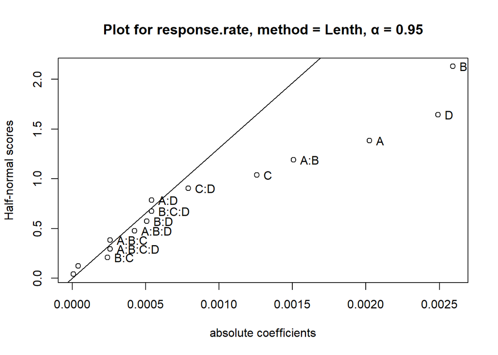

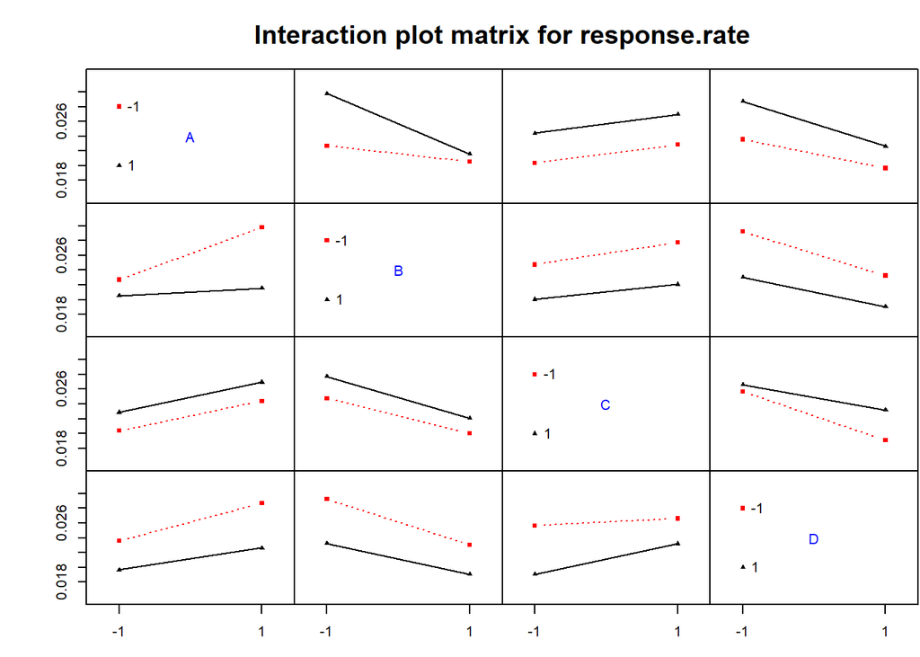

##### More steps were taken…..

#### Final model

```
##
## Call:
## lm.default(formula = response.rate ~ A * B * C * D - A:B:C:D -
##     A:C - A:C:D - B:C - A:B:C - A:B:D - B:C:D, data = df)
##
## Residuals:
##         Min          1Q      Median          3Q         Max
## -0.00177500 -0.00069167 -0.00000833  0.00067083  0.00167500
##
## Coefficients:
##               Estimate Std. Error t value        Pr(>|t|)
## (Intercept)  0.0236417  0.0003088  76.548 0.0000000000171 ***
## A            0.0020250  0.0003088   6.557        0.000317 ***
## B           -0.0025917  0.0003088  -8.391 0.0000671052387 ***
## C            0.0012583  0.0003088   4.074        0.004724 **
## D           -0.0024917  0.0003088  -8.068 0.0000863762608 ***
## A:B         -0.0015083  0.0003088  -4.884        0.001786 **
## A:D         -0.0005417  0.0003088  -1.754        0.122904
## B:D          0.0005083  0.0003088   1.646        0.143779
## C:D          0.0007917  0.0003088   2.563        0.037372 *
## ---
## Signif. codes:  0 '***' 0.001 '**' 0.01 '*' 0.05 '.' 0.1 ' ' 1
##
## Residual standard error: 0.001235 on 7 degrees of freedom
## Multiple R-squared:  0.9706, Adjusted R-squared:  0.9371
## F-statistic: 28.91 on 8 and 7 DF,  p-value: 0.0001087
```

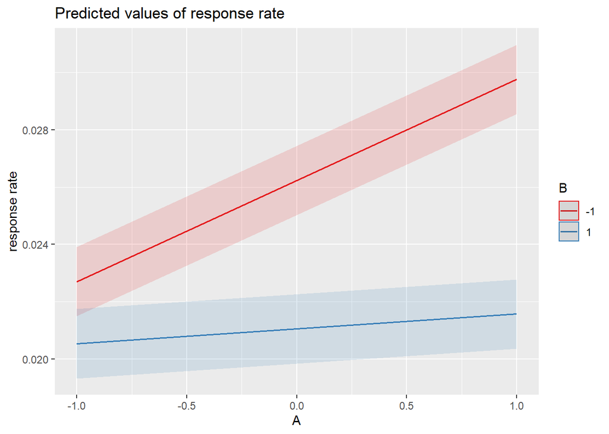

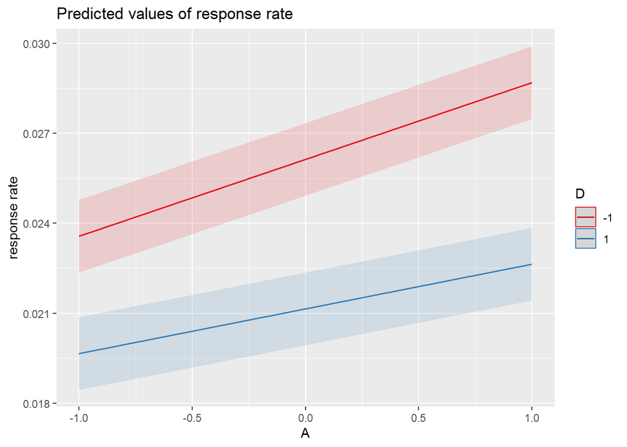

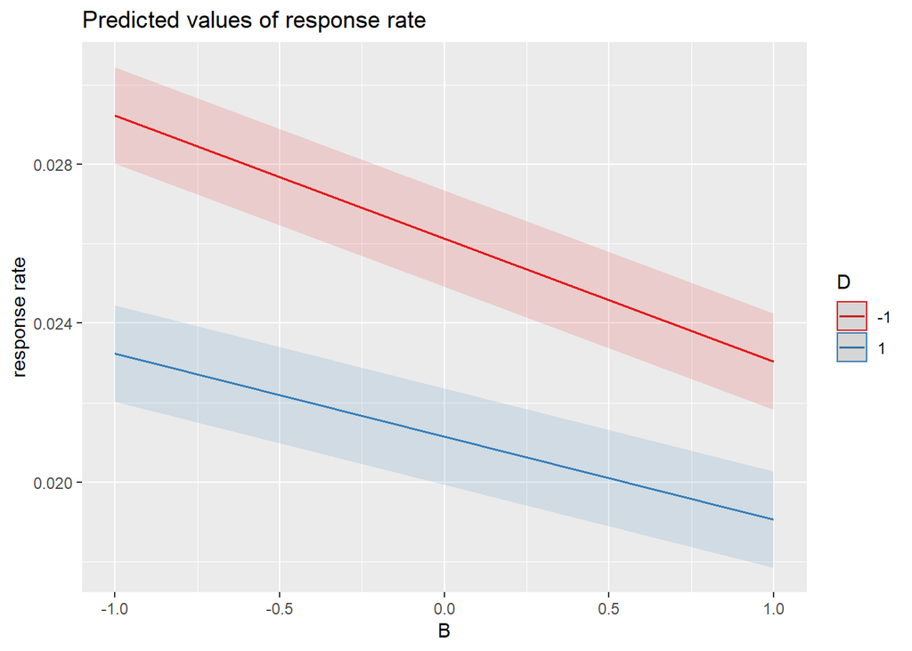

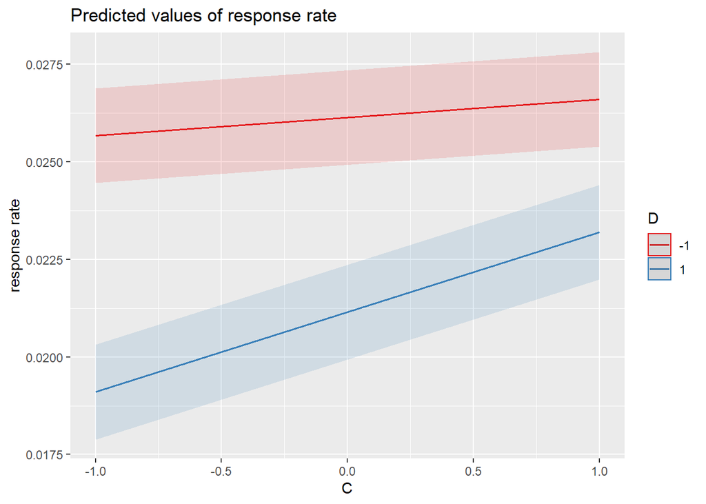

### Social Media Ad Testing

Vuori tested ads on Instagram. They ran an a/b test with two different versions of an ad. The response was a measure of user engagement on a scale of 0 to 100. The company also paid for user data from Instagram so they could have insight on who was engaging with the ad.

[figure not shown]

[figure not shown]

| ad | engagement | age | device |
| --- | --- | --- | --- |
| A | 85.51612 | 24 | Apple |
| A | 62.30687 | 45 | Apple |
| A | 69.48172 | 46 | Apple |
| A | 54.56918 | 31 | Apple |
| A | 98.10323 | 36 | Apple |
| A | 50.54667 | 17 | Apple |

#### Test of the Ad Effectiveness

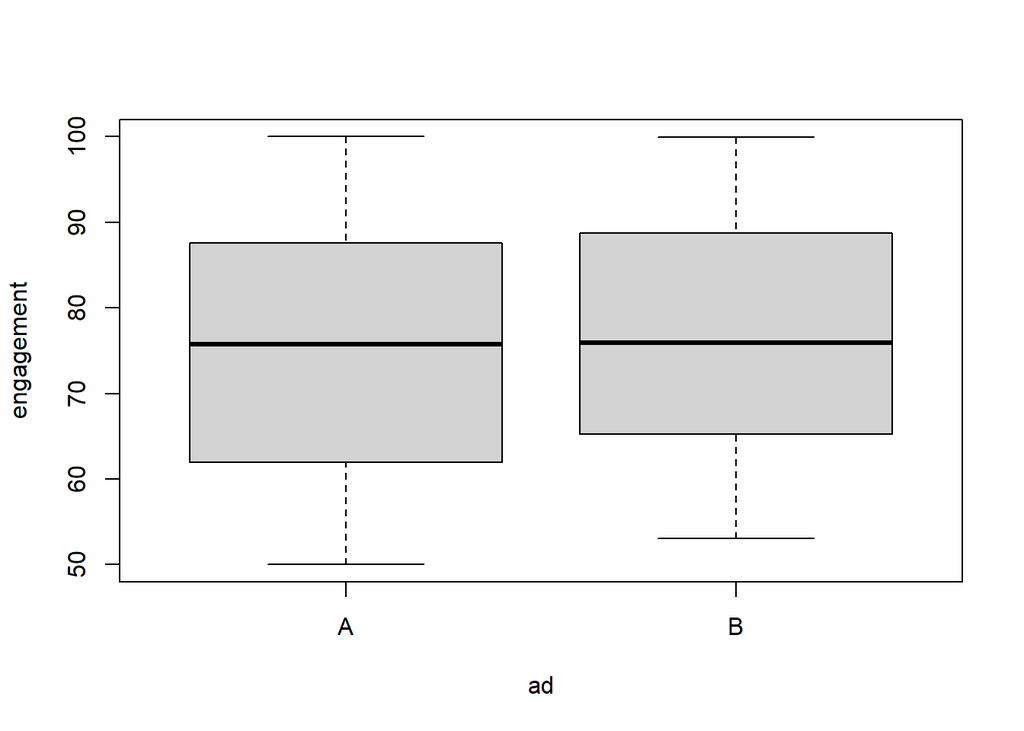

```r
boxplot(engagement~ad)
```

```r
t.test(engagement~ad, data=df)
```

```
##
##  Welch Two Sample t-test
##
## data:  engagement by ad
## t = -2.6043, df = 1977.9, p-value = 0.009274
## alternative hypothesis: true difference in means between group A and group B is not equal to 0
## 95 percent confidence interval:
##  -2.8685058 -0.4041082
## sample estimates:
## mean in group A mean in group B
##        75.01723        76.65354
```

#### Test of the Ad Effectiveness by Age

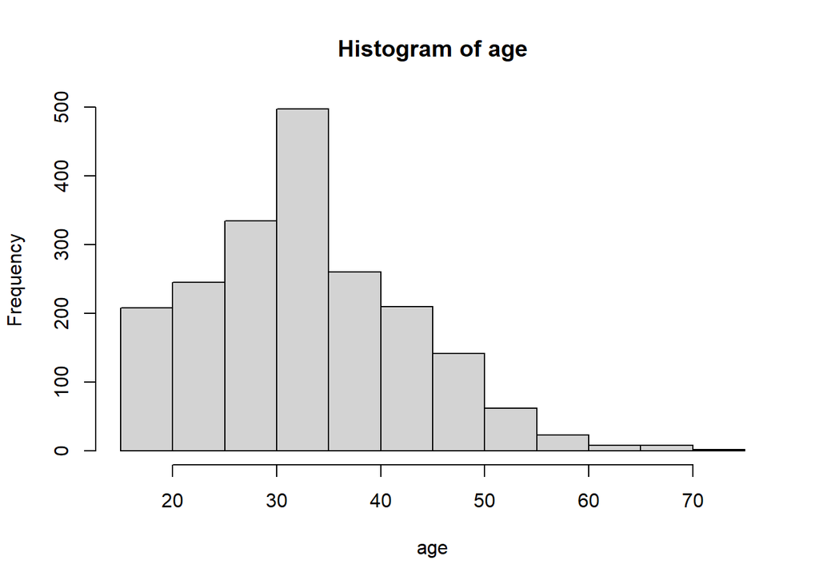

```r
hist(age)
```

```r
A<-(df$age<35)
B<-(df$age>=35)
t.test(df$engagement[A]~df$ad[A])
```

```
##
##  Welch Two Sample t-test
##
## data:  df$engagement[A] by df$ad[A]
## t = -1.887, df = 1210.2, p-value = 0.0594
## alternative hypothesis: true difference in means between group A and group B is not equal to 0
## 95 percent confidence interval:
##  -3.11425835  0.06063418
## sample estimates:
## mean in group A mean in group B
##        75.22132        76.74813
```

```r
t.test(df$engagement[B]~df$ad[B])
```

```
##
##  Welch Two Sample t-test
##
## data:  df$engagement[B] by df$ad[B]
## t = -1.8253, df = 763.05, p-value = 0.06835
## alternative hypothesis: true difference in means between group A and group B is not equal to 0
## 95 percent confidence interval:
##  -3.7827944  0.1375878
## sample estimates:
## mean in group A mean in group B
##        74.68846        76.51106
```

#### Test of device usage by Age

```r
t.test(df$age~df$device)
```

```
##
##  Welch Two Sample t-test
##
## data:  df$age by df$device
## t = 0.99765, df = 1588.9, p-value = 0.3186
## alternative hypothesis: true difference in means between group Android and group Apple is not equal to 0
## 95 percent confidence interval:
##  -0.4426229  1.3589472
## sample estimates:
## mean in group Android   mean in group Apple
##              33.52823              33.07006
```

### Data

| sex | years | income |
| --- | --- | --- |
| Male | 22 | 134668 |
| Male | 16 | 201487 |
| Male | 3 | 67186 |
| Male | 34 | 107868 |
| Male | 39 | 148175 |
| Male | 7 | 86439 |